# 7CS070/UZ3: Concepts & Technologies of Artificial Intelligence

## 2441638

```python
# Importing libraries for dataset handling and visualisation
import pandas as pd
import numpy as np
import matplotlib.pyplot as plt
%matplotlib inline
import seaborn as sns
import skimpy

# Import sklearn libraries for machine learning
from sklearn.ensemble import RandomForestRegressor
from sklearn.model_selection import train_test_split, GridSearchCV
from sklearn.preprocessing import StandardScaler, PowerTransformer
from sklearn.metrics import mean_squared_error, mean_absolute_error, r2_score
from sklearn.feature_selection import SelectKBest, f_regression
from sklearn.model_selection import cross_val_score
```

```python
# Reading in the dataset

data = pd.read_csv('/Users/mary-janeobijuru/Downloads/kc_house_data (2).csv')
```

```python
# Printing out the first 5 elements of the dataset to show the different features

data.head()
```

|  | price | bedrooms | bathrooms | sqft_living | sqft_lot | floors | grade | sqft_above | sqft_basement | yr_built | yr_renovated | lat | long | sqft_living15 | sqft_lot15 | condition |
| --- | --- | --- | --- | --- | --- | --- | --- | --- | --- | --- | --- | --- | --- | --- | --- | --- |
| 0 | 221900.0 | 3 | 1.00 | 1180 | 5650 | 1.0 | 7 | 1180 | 0 | 1955 | 0 | 47.5112 | -122.257 | 1340 | 5650 | 3 |
| 1 | 538000.0 | 3 | 2.25 | 2570 | 7242 | 2.0 | 7 | 2170 | 400 | 1951 | 1991 | 47.7210 | -122.319 | 1690 | 7639 | 3 |
| 2 | 180000.0 | 2 | 1.00 | 770 | 10000 | 1.0 | 6 | 770 | 0 | 1933 | 0 | 47.7379 | -122.233 | 2720 | 8062 | 3 |
| 3 | 604000.0 | 4 | 3.00 | 1960 | 5000 | 1.0 | 7 | 1050 | 910 | 1965 | 0 | 47.5208 | -122.393 | 1360 | 5000 | 5 |
| 4 | 510000.0 | 3 | 2.00 | 1680 | 8080 | 1.0 | 8 | 1680 | 0 | 1987 | 0 | 47.6168 | -122.045 | 1800 | 7503 | 3 |

```python
# To show brief summary statistics about the given housing dataset
# Summary highlights the size of dataset and number of numerical and categorical features,
# the feature names, number of missing feature values, mean, standard deviation, percentile scores and histogram
# of the feature distribution in the dataset

skimpy.skim(data)
```

```
╭──────────────────────────────────────────────── skimpy summary ─────────────────────────────────────────────────╮
│          Data Summary                Data Types                                                                 │
│ ┏━━━━━━━━━━━━━━━━━━━┳━━━━━━━━┓ ┏━━━━━━━━━━━━━┳━━━━━━━┓                                                          │
│ ┃ dataframe         ┃ Values ┃ ┃ Column Type ┃ Count ┃                                                          │
│ ┡━━━━━━━━━━━━━━━━━━━╇━━━━━━━━┩ ┡━━━━━━━━━━━━━╇━━━━━━━┩                                                          │
│ │ Number of rows    │ 21613  │ │ int64       │ 11    │                                                          │
│ │ Number of columns │ 16     │ │ float64     │ 5     │                                                          │
│ └───────────────────┴────────┘ └─────────────┴───────┘                                                          │
│                                                     number                                                      │
│ ┏━━━━━━━━━━━━━━━━━┳━━━━━┳━━━━━━━┳━━━━━━━━━┳━━━━━━━━━┳━━━━━━━━━┳━━━━━━━━━┳━━━━━━━━┳━━━━━━━━┳━━━━━━━━━┳━━━━━━━━┓  │
│ ┃ column_name     ┃ NA  ┃ NA %  ┃ mean    ┃ sd      ┃ p0      ┃ p25     ┃ p50    ┃ p75    ┃ p100    ┃ hist   ┃  │
│ ┡━━━━━━━━━━━━━━━━━╇━━━━━╇━━━━━━━╇━━━━━━━━━╇━━━━━━━━━╇━━━━━━━━━╇━━━━━━━━━╇━━━━━━━━╇━━━━━━━━╇━━━━━━━━━╇━━━━━━━━┩  │
│ │ price           │   0 │     0 │  540200 │  367400 │   75000 │  322000 │ 450000 │ 645000 │ 7700000 │   ▇    │  │
│ │ bedrooms        │   0 │     0 │   3.371 │  0.9301 │       0 │       3 │      3 │      4 │      33 │   ▇    │  │
│ │ bathrooms       │   0 │     0 │   2.115 │  0.7702 │       0 │    1.75 │   2.25 │    2.5 │       8 │  ▂▇▂   │  │
│ │ sqft_living     │   0 │     0 │    2080 │   918.4 │     290 │    1427 │   1910 │   2550 │   13540 │   ▇▃   │  │
│ │ sqft_lot        │   0 │     0 │   15110 │   41420 │     520 │    5040 │   7618 │  10690 │ 1651000 │   ▇    │  │
│ │ floors          │   0 │     0 │   1.494 │    0.54 │       1 │       1 │    1.5 │      2 │     3.5 │  ▇▁▆   │  │
│ │ grade           │   0 │     0 │   7.657 │   1.175 │       1 │       7 │      7 │      8 │      13 │   ▁▇▂  │  │
│ │ sqft_above      │   0 │     0 │    1788 │   828.1 │     290 │    1190 │   1560 │   2210 │    9410 │  ▇▅▁   │  │
│ │ sqft_basement   │   0 │     0 │   291.5 │   442.6 │       0 │       0 │      0 │    560 │    4820 │   ▇▁   │  │
│ │ yr_built        │   0 │     0 │    1971 │   29.37 │    1900 │    1951 │   1975 │   1997 │    2015 │ ▂▂▅▆▇▇ │  │
│ │ yr_renovated    │   0 │     0 │    84.4 │   401.7 │       0 │       0 │      0 │      0 │    2015 │   ▇    │  │
│ │ lat             │   0 │     0 │   47.56 │  0.1386 │   47.16 │   47.47 │  47.57 │  47.68 │   47.78 │  ▃▃▇▇▇ │  │
│ │ long            │   0 │     0 │  -122.2 │  0.1408 │  -122.5 │  -122.3 │ -122.2 │ -122.1 │  -121.3 │  ▅▇▃▁  │  │
│ │ sqft_living15   │   0 │     0 │    1987 │   685.4 │     399 │    1490 │   1840 │   2360 │    6210 │  ▂▇▃▁  │  │
│ │ sqft_lot15      │   0 │     0 │   12770 │   27300 │     651 │    5100 │   7620 │  10080 │  871200 │   ▇    │  │
│ │ condition       │   0 │     0 │   3.409 │  0.6507 │       1 │       3 │      3 │      4 │       5 │    ▇▃▁ │  │
│ └─────────────────┴─────┴───────┴─────────┴─────────┴─────────┴─────────┴────────┴────────┴─────────┴────────┘  │
╰────────────────────────────────────────────────────── End ──────────────────────────────────────────────────────╯
```

## Data Preprocessing

### The data is preprocessed to ensure that it is clean and can be used to train and test the model.

```python
# Underlining the statistics of the dataset using the describe function, which matches that of the skimpy summary above

data.describe()
```

|  | price | bedrooms | bathrooms | sqft_living | sqft_lot | floors | grade | sqft_above | sqft_basement | yr_built | yr_renovated | lat | long | sqft_living15 | sqft_lot15 | condition |
| --- | --- | --- | --- | --- | --- | --- | --- | --- | --- | --- | --- | --- | --- | --- | --- | --- |
| count | 2.161300e+04 | 21613.000000 | 21613.000000 | 21613.000000 | 2.161300e+04 | 21613.000000 | 21613.000000 | 21613.000000 | 21613.000000 | 21613.000000 | 21613.000000 | 21613.000000 | 21613.000000 | 21613.000000 | 21613.000000 | 21613.000000 |
| mean | 5.401822e+05 | 3.370842 | 2.114757 | 2079.899736 | 1.510697e+04 | 1.494309 | 7.656873 | 1788.390691 | 291.509045 | 1971.005136 | 84.402258 | 47.560053 | -122.213896 | 1986.552492 | 12768.455652 | 3.409430 |
| std | 3.673622e+05 | 0.930062 | 0.770163 | 918.440897 | 4.142051e+04 | 0.539989 | 1.175459 | 828.090978 | 442.575043 | 29.373411 | 401.679240 | 0.138564 | 0.140828 | 685.391304 | 27304.179631 | 0.650743 |
| min | 7.500000e+04 | 0.000000 | 0.000000 | 290.000000 | 5.200000e+02 | 1.000000 | 1.000000 | 290.000000 | 0.000000 | 1900.000000 | 0.000000 | 47.155900 | -122.519000 | 399.000000 | 651.000000 | 1.000000 |
| 25% | 3.219500e+05 | 3.000000 | 1.750000 | 1427.000000 | 5.040000e+03 | 1.000000 | 7.000000 | 1190.000000 | 0.000000 | 1951.000000 | 0.000000 | 47.471000 | -122.328000 | 1490.000000 | 5100.000000 | 3.000000 |
| 50% | 4.500000e+05 | 3.000000 | 2.250000 | 1910.000000 | 7.618000e+03 | 1.500000 | 7.000000 | 1560.000000 | 0.000000 | 1975.000000 | 0.000000 | 47.571800 | -122.230000 | 1840.000000 | 7620.000000 | 3.000000 |
| 75% | 6.450000e+05 | 4.000000 | 2.500000 | 2550.000000 | 1.068800e+04 | 2.000000 | 8.000000 | 2210.000000 | 560.000000 | 1997.000000 | 0.000000 | 47.678000 | -122.125000 | 2360.000000 | 10083.000000 | 4.000000 |
| max | 7.700000e+06 | 33.000000 | 8.000000 | 13540.000000 | 1.651359e+06 | 3.500000 | 13.000000 | 9410.000000 | 4820.000000 | 2015.000000 | 2015.000000 | 47.777600 | -121.315000 | 6210.000000 | 871200.000000 | 5.000000 |

```python
# Checking the feature variable datatypes and that there are no missing values for each row
data.info()
```

```
<class 'pandas.core.frame.DataFrame'>
RangeIndex: 21613 entries, 0 to 21612
Data columns (total 16 columns):
 #   Column         Non-Null Count  Dtype
---  ------         --------------  -----
 0   price          21613 non-null  float64
 1   bedrooms       21613 non-null  int64
 2   bathrooms      21613 non-null  float64
 3   sqft_living    21613 non-null  int64
 4   sqft_lot       21613 non-null  int64
 5   floors         21613 non-null  float64
 6   grade          21613 non-null  int64
 7   sqft_above     21613 non-null  int64
 8   sqft_basement  21613 non-null  int64
 9   yr_built       21613 non-null  int64
 10  yr_renovated   21613 non-null  int64
 11  lat            21613 non-null  float64
 12  long           21613 non-null  float64
 13  sqft_living15  21613 non-null  int64
 14  sqft_lot15     21613 non-null  int64
 15  condition      21613 non-null  int64
dtypes: float64(5), int64(11)
memory usage: 2.6 MB
```

```python
# Printing out the size of the dataset to match the cell above i.e. ensure that no rows has null value
data.shape
```

```
(21613, 16)
```

The boxplots show a significant number of outliers present for the price, no. bedrooms, no. bathrooms, sqft living, sqft lot, grade, sqft above, sqft basement, year renovated, lat, long, sqft_living15, sqft_lot15, and also the condition variable. The most extreme outliers are the in the year renovated variable

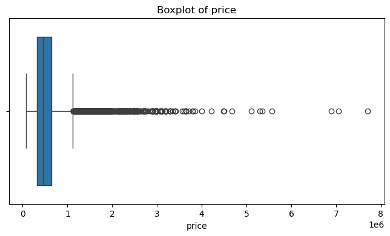

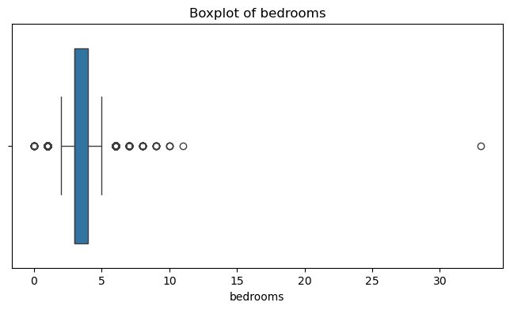

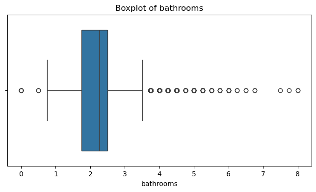

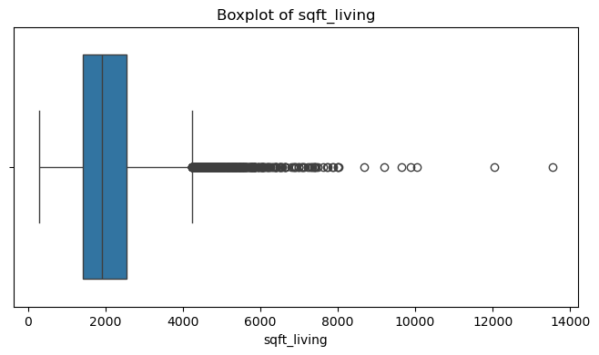

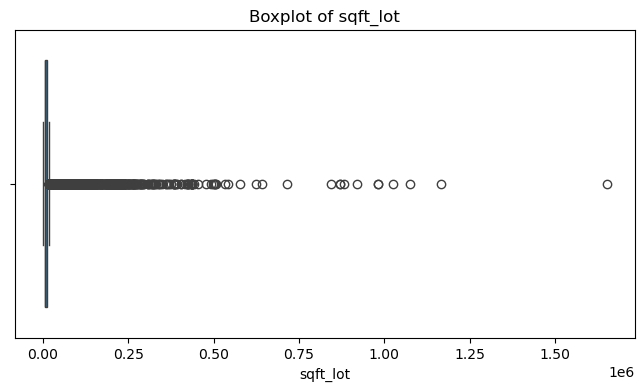

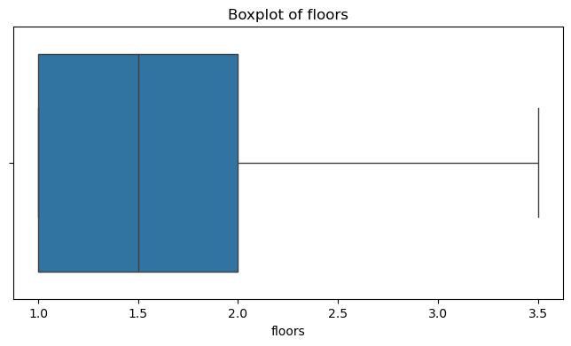

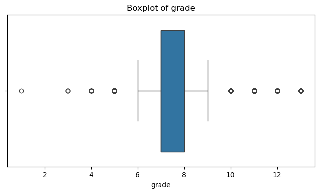

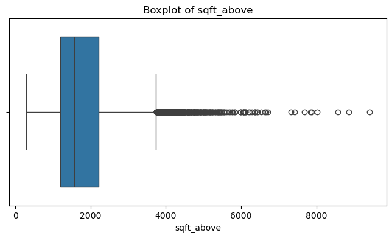

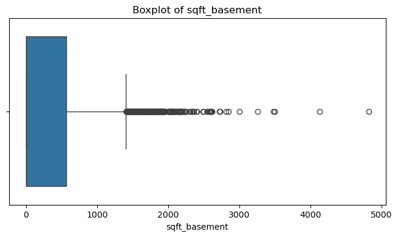

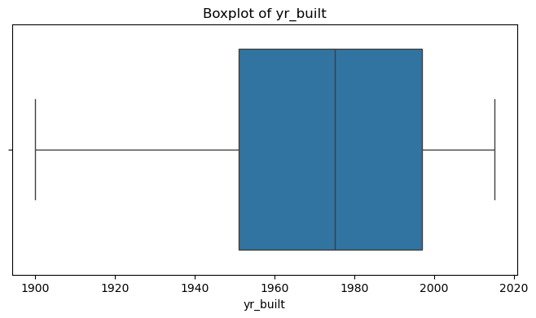

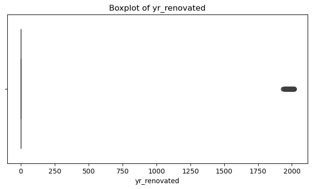

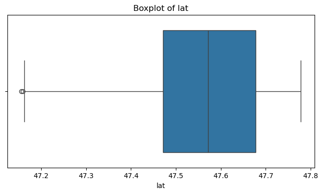

[4 more figures not shown]

```python
# Displaying a box plot distribution for each of the features in the dataset, indicicating the mean values, feature variation in respect to
# the lower and upper quartile values, and outliers denoted as circles

for col in data.columns:
    plt.figure(figsize=(8, 4))
    sns.boxplot(x=data[col])
    plt.title(f"Boxplot of {col}")
    plt.show()
```